# 每週一圖作業

#### 環境設定

以下為老師執行時一定會存在的環境設定

```r
knitr::opts_chunk$set(echo = TRUE)
library(dplyr); library(stringr); library(ggplot2); library(plotly); library(lubridate); library(readr);
library(tidyr); library(showtext)

font_add(family="QYuan",regular="cwTeXQYuan-Medium.ttf")
showtext_auto(enable=TRUE) #啟用字體
theme_set(theme_classic())
knitr::opts_chunk$set(out.width='80%', fig.asp=.75, fig.align='center', fig.showtext=T)

library(grDevices) # 不同顏色模型代碼的呈現及轉換
library(scales) # show_col()螢幕立即顯示顏色
library(colorspace) # 調色盤選擇及ggplot應用工具
library(shinyjs) # 支援套件
```

#### 資料處理

此部份在做：

- 原始Rda資料引入（即引入**dataList**物件）；
- 資料清理成作圖用graphData物件。

請將你最原始的資料連同作業一起上傳到作業上傳網址：  
* 若「原始資料為網頁下載」，且下載指令寫在data cleaning chunk裡的話，可以不用上傳「資料」。  
* 若原始資料有很多個檔案，請先引入成data frame並存在「一個」.Rda檔裡上傳（如`example_data.Rda`檔）。

資料檔引入到進入作圖前的資料處理請寫在下面區塊，分二部份：

- 資料處理
- 作圖用資料物件生成(最後形成作圖資料物件graphData)

```r
#資料載入
library(readr)
nearsightedStud_sorted <- read_csv("nearsighted_sorted.csv",
    locale = locale(encoding = "BIG5"))
```

```r
#View(nearsightedStud_sorted)

save(nearsightedStud_sorted, file="uploadfile.Rda")

load("uploadfile.Rda")

graphData <- list()

#choose_palette(gui = "shiny")

#資料整理

nearsightedStud_sorted %>%
  gather(`2014`,`2015`,`2016`,`2017`,`2018`,key = "年分",value = "近視學生人數")%>%
  group_by(級別,年分)%>%
  summarise(
    總近視學生人數 = sum(近視學生人數))%>%ungroup->nearsightedStud_sorted
slice(nearsightedStud_sorted,1:15)-> nearsightedStud_sorted
filter(nearsightedStud_sorted,nearsightedStud_sorted$年分 == "2016" | nearsightedStud_sorted$年分 == "2017"|nearsightedStud_sorted$年分 == "2018") -> nearsightedStud_sorted
nearsightedStud_sorted -> graphData$nearsightedStud
```

#### 繪圖程式

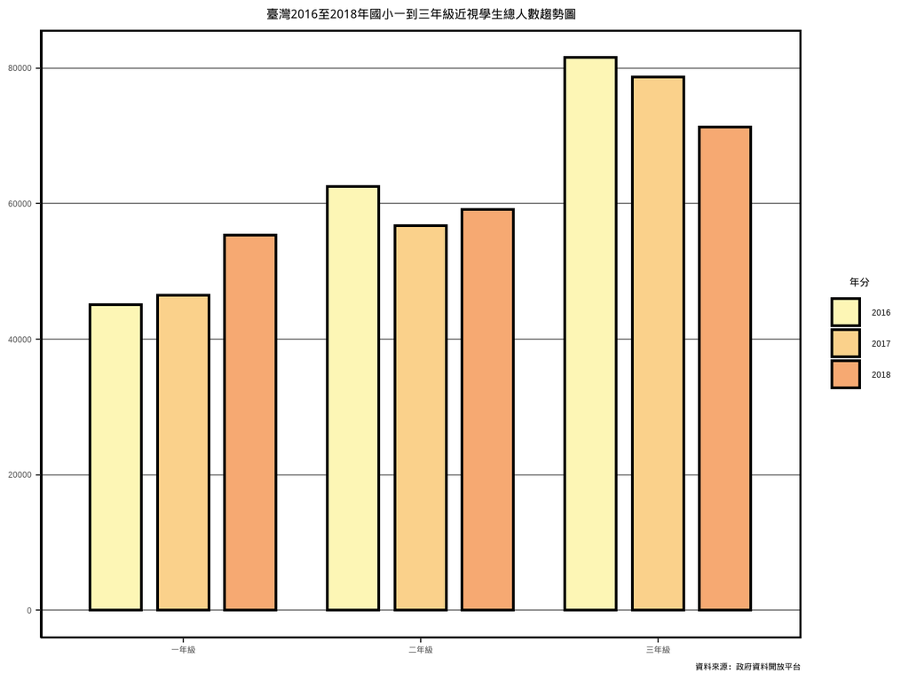

```r
colorspace::sequential_hcl(n = 7, h = c(-4, 80), c = c(100, NA, 47), l = c(55, 96), power = c(1, NA), register = "YEAR-Palette")

graphData$nearsightedStud%>%
  ggplot()+
  geom_col(
    aes(
      x = 級別,
      y = 總近視學生人數,
      fill = 年分
      ),
    position = position_dodge(0.85),
    width =0.65,
    color = "black",
    linetype = "solid",
    size = 0.76
    )+
  scale_fill_discrete_sequential(
    palette = "YEAR-Palette",
    nmax = 5
    )+
  scale_x_discrete(
    breaks = c("國小一年級","國小二年級","國小三年級"),
    labels = c("一年級","二年級","三年級")
  )+
  theme(
  panel.background = element_rect(fill = NA),
  panel.grid = element_line(colour = "black", size = 5),
  panel.ontop = F,
  panel.grid.major.y = element_line(colour = "gray50"),
  panel.border =  element_rect(fill = NA,size = 1)
)+
  labs(
    title = "臺灣2016至2018年國小一到三年級近視學生總人數趨勢圖",
    caption = "資料來源：政府資料開放平台")+
  theme(
    plot.title = element_text(hjust = 0.5),
    legend.title.align = 0.5,
    axis.title.x.bottom = element_blank(),
    axis.title.y.left = element_blank()
    ) -> graphData$nearsightedStud

graphData$nearsightedStud
```

#### 設計說明

說明想傳達的訊息（必要）及設計想法（非必要）。寫在***之後

臺灣 2016 至 2018 年國小一年級至三年級近視學生總人數趨勢圖：

左方資料圖顯示國小一、二、三年級分別的各年度近視學生人數。從趨勢上分析，一年級人數有增加現象，尤其在 2018 年時(與前一年比較)上升幅度最大；二年級人數在 2017 年時減少，但在 2018 年時稍微回升，高峰時間是 2016 年；三年級人數是三級別中總數最多的，且在 2016 至 2018 年期間逐漸下降。

設計想法：

作圖者想呈現國小各年級在不同年度的人數趨勢，因此 X 軸以級別為類別，用漸層色的長條圖顯示其各年度之間的變化。